# S-Mobile: Predicting Customer Churn

- Team-lead gitlab id: rsm-jcepela
- Group number: 10
- Group name: The Nameless
- Team member names: Zhengyu Jiang, Xi Jiang, Qiuyi Lu, Jake Cepela

## Setup

Please complete this Rmarkdown document by answering the questions in `s-mobile.pdf` on Canvas (week9/). The code block below will load the data you will need. Please DO NOT change the code used to load the data. Create an HTML file with all your results and comments and push both the Rmarkdown and HTML file to GitLab when you are done. All analysis results MUST be reproducible (i.e., the TA and I must be able to recreate the HTML from the Rmarkdown file without changes or errors). Upload all files to GitLab.

This is the fourth group assignment for MGTA 455 and you will be using git and GitLab. If two people edit the same file at the same time you could get what is called a “merge conflict”. git will not decide for you who’s change to accept so the team-lead will have to determine which edits to use. To avoid merge conflicts, always “pull” changes to the repo before you start working on any files. Then, when you are done, save and commit your changes, and then push them to GitLab. Make “pull first” a habit!

```r
## Loading and split the data from Dropbox
s_mobile <- readr::read_rds("data/s_mobile.rds") %>% mutate(cweight = ifelse(churn == "yes", 1L, 49L))
train <- filter(s_mobile, training == 1)
test <- filter(s_mobile, training == 0)
representative <- filter(s_mobile, representative == 1)
```

```r
# Show descriptive statistics in the training data
result <- explore(
  train,
  vars = c(
    "churn", "changer", "changem", "revenue", "mou", "overage", "roam", "conference", "months", "uniqsubs",
    "custcare", "retcalls", "dropvce", "eqpdays", "refurb", "smartphone", "highcreditr", "mcycle", "car",
    "travel", "region", "occupation"
  ),
  fun = c("mean", "sd", "min", "max"),
  nr = Inf
)
summary(result)
```

```
Explore
Data        : train
Functions   : mean, sd, min, max
Top         : Function

    variable    mean      sd min   max
       churn   0.500   0.500   1     2
     changer   8.661  28.957 -62   305
     changem  15.211  51.886 -78   521
     revenue  57.211  43.259   0   856
         mou 515.322 525.459   0 7,668
     overage  66.274  69.258   0   283
        roam   1.197   7.254   0   692
  conference   0.263   1.084   0    56
      months  18.782   9.596   6    61
    uniqsubs   1.546   0.891   1    18
    custcare   2.288   4.193   0    32
    retcalls   0.043   0.222   0     4
     dropvce   2.946   4.404   0    67
     eqpdays 355.691 232.333   0 1,799
      refurb   0.856   0.351   1     2
  smartphone   0.103   0.304   1     2
 highcreditr   0.863   0.344   1     2
      mcycle   0.812   0.391   1     2
         car   0.908   0.289   1     2
      travel   0.944   0.230   1     2
      region   0.239   0.427   1     5
  occupation   0.629   0.483   1     4
```

```r
# dtab(result)
stats <- result$tab
```

```r
# Show churn in the representative sample
result <- explore(
  representative,
  vars = "churn",
  fun = "mean",
  nr = Inf
)
summary(result)
```

```
Explore
Data        : representative
Functions   : mean
Top         : Function

 variable  mean
    churn 0.020
```

```r
# dtab(result)
```

## Question answers

### Logistic Model

```r
result_27k <- logistic(
  train,
  rvar = "churn",
  evar = c(
    "changer", "changem","revenue", "mou", "overage", "roam",
    "months", "uniqsubs", "custcare", "retcalls", "dropvce",
    "eqpdays", "refurb", "smartphone", "highcreditr", "mcycle",
    "travel", "region", "occupation"
  ),
  lev = "yes",
  wts = "cweight",
  check = "standardize"
)

pred <- predict(result_27k, pred_data = s_mobile)
s_mobile <- store(s_mobile, pred, name = "p_base")
pred <- predict(result_27k, pred_data = test)
test <- store(test, pred, name = "pred_logit")
auc(test$pred_logit, test$churn == 'yes')
```

```
[1] 0.6944061
```

```r
write.coeff(result_27k,sort=T)
```

```
Standardized coefficients selected
```

```
                     label        OR coefficient  std.error     z.value       p.value sig_star dummy         mean          sd min  max importance
1              (Intercept) 0.0000000 -3.46040887 0.03364592 -102.847793  0.000000e+00      ***     0   1.00000000   0.0000000   1    1   0.000000
2       occupation|retired 0.1844728 -1.69025346 0.05400346  -31.298985 4.817027e-215      ***     1   0.08322344   0.2762247   0    1   5.420855
3          highcreditr|yes 0.4831770 -0.72737227 0.03067993  -23.708405 2.953314e-124      ***     1   0.13688645   0.3437337   0    1   2.069635
4       occupation|student 1.8991099  0.64138533 0.03048623   21.038526  2.912923e-98      ***     1   0.07615385   0.2652490   0    1   1.899110
5                  eqpdays 1.8259192  0.60208352 0.02214324   27.190402 8.434863e-163      ***     0 355.69131868 232.3331895   0 1799   1.825919
6                  overage 1.7870834  0.58058493 0.02255260   25.743588 3.802999e-146      ***     0  66.27428571  69.2580678   0  283   1.787083
7                region|SW 0.6272032 -0.46648475 0.02642875  -17.650652  1.005884e-69      ***     1   0.18996337   0.3922791   0    1   1.594380
8                region|NE 0.6444539 -0.43935202 0.02645322  -16.608642  6.034421e-62      ***     1   0.18827839   0.3909415   0    1   1.551701
9                region|SE 0.6505678 -0.42990977 0.02618582  -16.417658  1.429787e-60      ***     1   0.19142857   0.3934328   0    1   1.537119
10               region|NW 0.6602990 -0.41506252 0.02619790  -15.843351  1.562671e-56      ***     1   0.19124542   0.3932890   0    1   1.514465
11                     mou 0.6749141 -0.39316986 0.03536279  -11.118179  1.023396e-28      ***     0 515.32230769 525.4589251   0 7668   1.481670
12                  months 0.7050035 -0.34955253 0.02262981  -15.446549  7.959255e-54      ***     0  18.78150183   9.5956143   6   61   1.418433
13 occupation|professional 1.4155959  0.34755058 0.02176107   15.971210  2.028116e-57      ***     1   0.21208791   0.4087943   0    1   1.415596
14              refurb|yes 1.3182884  0.27633420 0.02508237   11.017070  3.161829e-28      ***     1   0.14362637   0.3507169   0    1   1.318288
15              travel|yes 0.7811472 -0.24699165 0.03934707   -6.277257  3.445975e-10      ***     1   0.05578755   0.2295152   0    1   1.280168
16                retcalls 1.2439369  0.21828127 0.01226668   17.794648  7.775465e-71      ***     0   0.04252747   0.2221832   0    4   1.243937
17                 changem 0.8644761 -0.14563160 0.02051904   -7.097390  1.271353e-12      ***     0  15.21139194  51.8855768 -78  521   1.156770
18              mcycle|yes 0.8793898 -0.12852700 0.02263997   -5.676994  1.370819e-08      ***     1   0.18820513   0.3908830   0    1   1.137152
19                 dropvce 1.1309728  0.12307814 0.02264028    5.436247  5.441456e-08      ***     0   2.94633700   4.4043010   0   67   1.130973
20                    roam 1.0970822  0.09265407 0.01381608    6.706246  1.996943e-11      ***     0   1.19725275   7.2543265   0  692   1.097082
21          smartphone|yes 0.9125434 -0.09151963 0.02990686   -3.060155  2.212226e-03      **      1   0.89692308   0.3040649   0    1   1.095838
22                uniqsubs 1.0659369  0.06385415 0.01679738    3.801435  1.438604e-04      ***     0   1.54622711   0.8910515   1   18   1.065937
23                 changer 1.0651938  0.06315672 0.01874940    3.368466  7.558761e-04      ***     0   8.66124542  28.9568225 -62  305   1.065194
24                 revenue 0.9562521 -0.04473367 0.02892730   -1.546417  1.220039e-01              0  57.21113553  43.2589496   0  856   1.045749
25                custcare 0.9726666 -0.02771387 0.02230804   -1.242327  2.141161e-01              0   2.28813187   4.1929696   0   32   1.028101
```

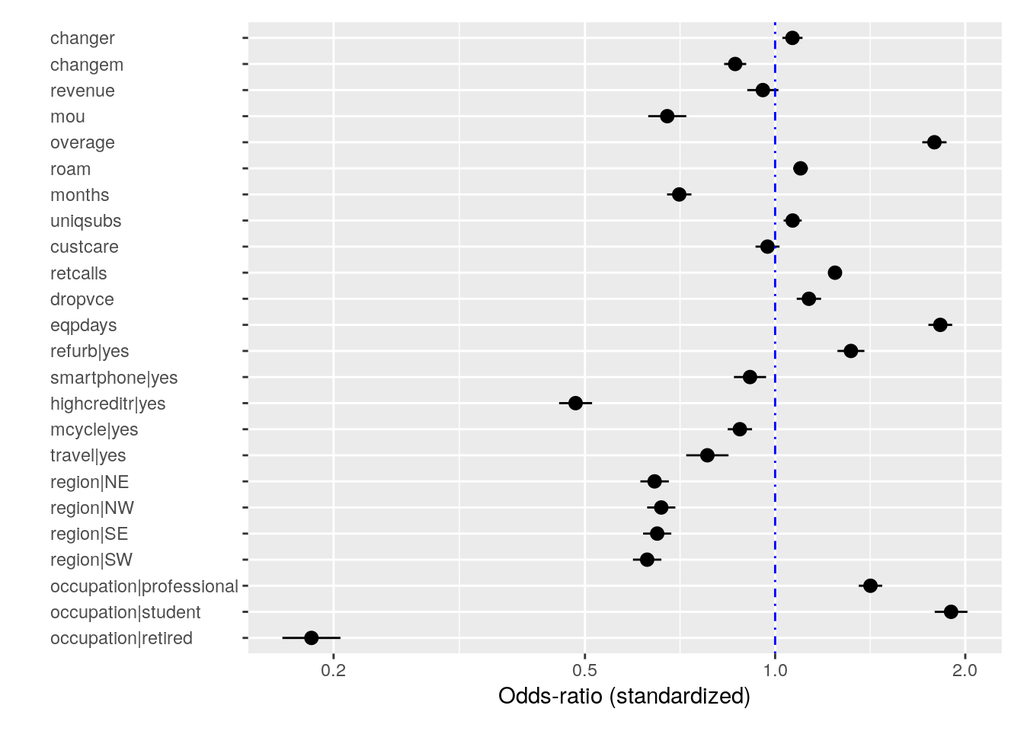

```r
plot(result_27k, custom = FALSE)
```

### Best NN model

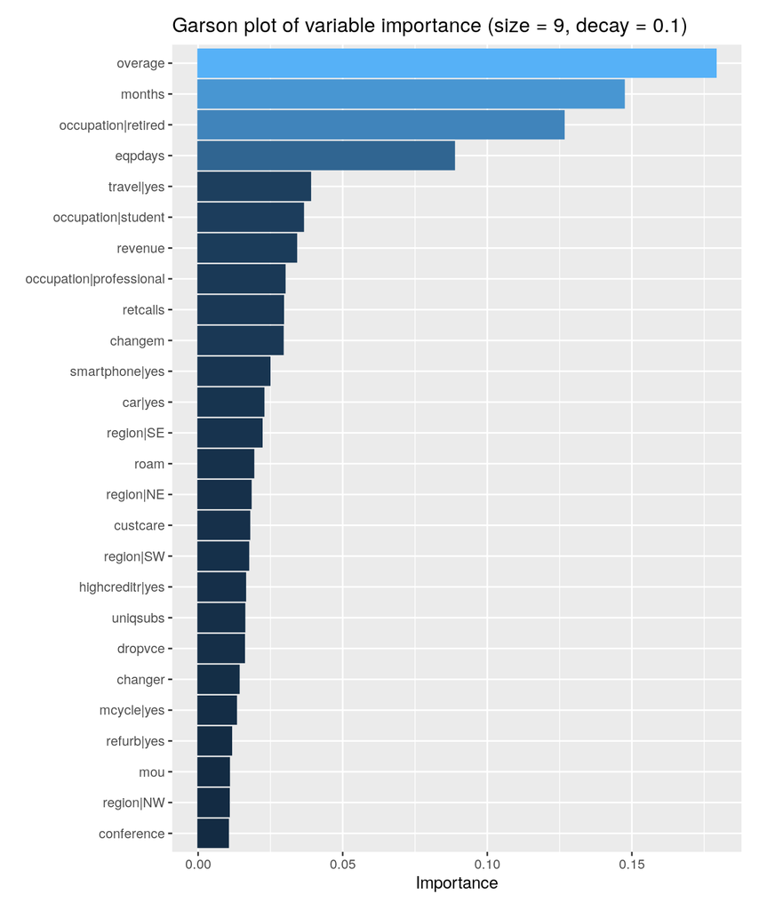

```r
result_main <- nn(
  train,
  rvar = "churn",
  evar = c(
    "changer", "changem", "revenue", "mou", "overage", "roam",
    "conference", "months", "uniqsubs", "custcare", "retcalls",
    "dropvce", "eqpdays", "refurb", "smartphone", "highcreditr",
    "mcycle", "car", "travel", "region", "occupation"
  ),
  lev = "yes",
  size = 9,
  decay = 0.1,
  wts = "cweight",
  seed = 1234
)
# summary(result, prn = TRUE)
plot(result_main, plots = "garson", custom = FALSE)
```

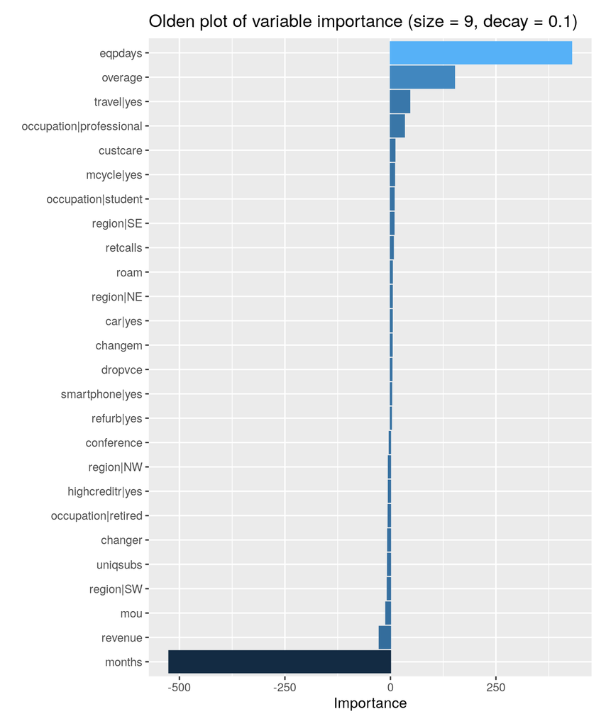

```r
plot(result_main, plots = "olden", custom = FALSE)
```

```r
pred <- predict(result_main, pred_data = test)
test <- store(test, pred, name = "pred_logit")
auc(test$pred_logit, test$churn == 'yes')
```

```
[1] 0.7414182
```

```r
pred <- predict(result_main, pred_data = representative)
representative <- store(representative, pred, name = "p_base")
```

## Calculate the churn rate for two actions

```r
# action 1: provide new plans to reduce the overage
pred <- predict(result_main, pred_data = representative, pred_cmd = "overage = 0")
representative <- store(representative, pred, name = "p_overage0")

result <- explore(
  representative,
  vars = c("churn", "p_overage0"),
  fun = c("n_obs", "mean"),
  data_filter = "overage > 0",
  nr = Inf
)
summary(result)
```

```
Explore
Data        : representative
Filter      : overage > 0
Functions   : n_obs, mean
Top         : Function

   variable  n_obs  mean
      churn 16,264 0.024
 p_overage0 16,264 0.014
```

```r
# action 2: seduce customers to get a new cell phone with a discount of $80
pred <- predict(result_main, pred_data = representative, pred_cmd = "eqpdays = 0")
representative <- store(representative, pred, name = "p_eqpdays0")

result <- explore(
  representative,
  vars = c("churn", "p_eqpdays0"),
  fun = c("n_obs", "mean"),
  data_filter = "eqpdays > 600",
  nr = Inf
)
summary(result)
```

```
Explore
Data        : representative
Filter      : eqpdays > 600
Functions   : n_obs, mean
Top         : Function

   variable n_obs  mean
      churn 3,767 0.025
 p_eqpdays0 3,767 0.014
```

```r
# define a fuction to calculate CLVs and difference
CLV_diff <- function(monthly_revenue, churn_base, churn_new) {
  nr_years <- 5
  churns <- rep(churn_base, nr_years * 12)
  monthly_discount_rate <- 0.008
  retention_nap <- c(1, cumprod(1 - churns))[1:60]
  revenues <- rep(monthly_revenue, nr_years)
  time <- 0:((nr_years * 12) - 1)
  exp_profit <- retention_nap * revenues * 0.4
  PV_exp_profit <- exp_profit / (1 + monthly_discount_rate)^time
  CLV_base <- cumsum(PV_exp_profit)[60]

  nr_years <- 5
  churns <- rep(churn_new, nr_years * 12)
  monthly_discount_rate <- 0.008
  retention_nap <- c(1, cumprod(1 - churns))[1:60]
  revenues <- rep(monthly_revenue, nr_years)
  time <- 0:((nr_years * 12) - 1)
  exp_profit <- retention_nap * revenues * 0.4
  PV_exp_profit <- exp_profit / (1 + monthly_discount_rate)^time
  CLV_new <- cumsum(PV_exp_profit)[60]

  p <- CLV_new - CLV_base
  return(c(CLV_base, CLV_new, p))
}
```

### Evaluation of economics(for 1M customers)

```r
# action 1: 100% acception
t <- representative %>% filter(overage > 0)

clv_diff <- CLV_diff(mean(t$revenue), 0.024, 0.014)

perc <- length(t$churn)/30000
profit_change <- 1000000 * perc * clv_diff[3]


clv_overage=data.frame(orginal_clv=clv_diff[1],new_clv=clv_diff[2],diff_clv=clv_diff[3],scaled_profit=profit_change)

# action 2: 50% acception with $80 discount
t <- representative %>% filter(eqpdays > 600)

clv_diff <- CLV_diff(mean(t$revenue), 0.025, 0.014)

marg <- clv_diff - 80
perc <- 0.5 * length(t$churn)/30000
profit_change <- 1000000 * perc * clv_diff[3]

clv_eqpdays=data.frame(orginal_clv=clv_diff[1],new_clv=clv_diff[2],diff_clv=clv_diff[3],scaled_profit=profit_change)

clv_profit=rbind(clv_eqpdays,clv_overage)%>% mutate(actioin=c("decrease eqpdays","decrease overage"))
clv_profit
```

```
  orginal_clv  new_clv diff_clv scaled_profit          actioin
1    438.3785 558.4002 120.0217       7535361 decrease eqpdays
2    747.0801 932.0679 184.9879     100288080 decrease overage
```